# VAST challenge 2018 Mini Challenge 2

### by: Mary Etokwudo, etokwudomary@gmail.com

1. Introduction
2. Data Preprocessing/Cleaning
3. Collection Frequency
4. Identifying Missing Data  
   i. Calendar Heat Map  
   ii. Calendar Heat Map - by location
5. Analysing the measures  
   i. Non-visual analysis of measures  
   ii. Visual Analysis of individual measures (Iron)  
   iii. Layered Timeseries Chart for Iron  
   iv. Interval Selection chart for Water Temperature
6. Visulaizing the map of the locations
7. Creating Location-Measure Time Series Dashboard

# Introduction

VAST challenge is an annual international visual analytics competition. It provides a dataset and a few analysis questions. Each entry needs to present:

1. The visual analytics tool they developed and
2. How they found the answers using the tool

### Background

(All the people, places, groups, technologies, contained therein are fictitious.)

Mistford is a mid-size city to the southwest of the Boonsong Lekagul Wildlife Preserve. The city has a small industrial area with four light-manufacturing endeavors. Mistford and the wildlife preserve are struggling with the possible endangerment of the Rose-Crested Blue Pipit, a locally loved bird. The birdʼs nesting pairs seem to have decreased alarmingly.

An investigation last year (VAST challenge 2017) indicated that the Kasios Office Furniture, a Mistford manufacturing firm, may be linked to this Though there is no firm evidence. Now the company insists that they have done nothing wrong. It is time for more visual analytics investigation.

### Dataset

Several years of water sensor readings from rivers and streams in the preserve. These samples were taken from different locations scattered throughout the area. It contains measurements of several chemicals of possible interest.  
The task is to investigate the sensor readings to find possible link to the bird population deduction.

### Solution

The visualisation tool used in this analysis is [Vega-Altair](https://altair-viz.github.io/)

# Data Preprocessing

```python
import pandas as pd
from IPython.display import Image, Markdown, display
import altair as alt
from altair import datum
alt.data_transformers.enable('data_server')
```

```
DataTransformerRegistry.enable('data_server')
```

```python
df_original = pd.read_csv("Boonsong Lekagul waterways readings.csv")
```

In order not to tamper with the original dataset, I will be making a copy

```python
df = df_original.copy()
```

```python
df.head()
```

|  | id | value | location | sample date | measure |
| --- | --- | --- | --- | --- | --- |
| 0 | 2221 | 2.00 | Boonsri | 11-Jan-98 | Water temperature |
| 1 | 2223 | 9.10 | Boonsri | 11-Jan-98 | Dissolved oxygen |
| 2 | 2227 | 0.33 | Boonsri | 11-Jan-98 | Ammonium |
| 3 | 2228 | 0.01 | Boonsri | 11-Jan-98 | Nitrites |
| 4 | 2229 | 1.47 | Boonsri | 11-Jan-98 | Nitrates |

```python
# get the size of the dataset
df.shape
```

```
(136824, 5)
```

```python
df.info()
```

```
<class 'pandas.core.frame.DataFrame'>
RangeIndex: 136824 entries, 0 to 136823
Data columns (total 5 columns):
 #   Column       Non-Null Count   Dtype
---  ------       --------------   -----
 0   id           136824 non-null  int64
 1   value        136824 non-null  float64
 2   location     136824 non-null  object
 3   sample date  136824 non-null  object
 4   measure      136824 non-null  object
dtypes: float64(1), int64(1), object(3)
memory usage: 5.2+ MB
```

There is a total of 136824 rows and an equal amount of values for each column. This means that no row/column has missing values.

Checking for duplicates

```python
duplicates = df[df.duplicated()]
duplicates
```

|  | id | value | location | sample date | measure |
| --- | --- | --- | --- | --- | --- |

There are no duplcate rows (readings) in the dataset

The `sample date` variable is in object data type. For better analysis, this will be converted to date type. The name format for the column will also be changed to avoid msitakes when referencing the column.

```python
df["sample_date"] = pd.to_datetime(df["sample date"])
```

```python
# drop the old column
df.drop(["sample date"], axis = 1, inplace = True)
```

```python
df.info()
```

```
<class 'pandas.core.frame.DataFrame'>
RangeIndex: 136824 entries, 0 to 136823
Data columns (total 5 columns):
 #   Column       Non-Null Count   Dtype
---  ------       --------------   -----
 0   id           136824 non-null  int64
 1   value        136824 non-null  float64
 2   location     136824 non-null  object
 3   measure      136824 non-null  object
 4   sample_date  136824 non-null  datetime64[ns]
dtypes: datetime64[ns](1), float64(1), int64(1), object(2)
memory usage: 5.2+ MB
```

```python
df.head()
```

|  | id | value | location | measure | sample_date |
| --- | --- | --- | --- | --- | --- |
| 0 | 2221 | 2.00 | Boonsri | Water temperature | 1998-01-11 |
| 1 | 2223 | 9.10 | Boonsri | Dissolved oxygen | 1998-01-11 |
| 2 | 2227 | 0.33 | Boonsri | Ammonium | 1998-01-11 |
| 3 | 2228 | 0.01 | Boonsri | Nitrites | 1998-01-11 |
| 4 | 2229 | 1.47 | Boonsri | Nitrates | 1998-01-11 |

To aid with data aggregation by date, the day, month and year have to be extracted from the sample_date feature

```python
df['day'] = pd.DatetimeIndex(df['sample_date']).day
df['month'] = pd.DatetimeIndex(df['sample_date']).strftime('%b')
df['year'] = pd.DatetimeIndex(df['sample_date']).year
```

```python
df.head()
```

|  | id | value | location | measure | sample_date | day | month | year |
| --- | --- | --- | --- | --- | --- | --- | --- | --- |
| 0 | 2221 | 2.00 | Boonsri | Water temperature | 1998-01-11 | 11 | Jan | 1998 |
| 1 | 2223 | 9.10 | Boonsri | Dissolved oxygen | 1998-01-11 | 11 | Jan | 1998 |
| 2 | 2227 | 0.33 | Boonsri | Ammonium | 1998-01-11 | 11 | Jan | 1998 |
| 3 | 2228 | 0.01 | Boonsri | Nitrites | 1998-01-11 | 11 | Jan | 1998 |
| 4 | 2229 | 1.47 | Boonsri | Nitrates | 1998-01-11 | 11 | Jan | 1998 |

```python
df.info()
```

```
<class 'pandas.core.frame.DataFrame'>
RangeIndex: 136824 entries, 0 to 136823
Data columns (total 8 columns):
 #   Column       Non-Null Count   Dtype
---  ------       --------------   -----
 0   id           136824 non-null  int64
 1   value        136824 non-null  float64
 2   location     136824 non-null  object
 3   measure      136824 non-null  object
 4   sample_date  136824 non-null  datetime64[ns]
 5   day          136824 non-null  int64
 6   month        136824 non-null  object
 7   year         136824 non-null  int64
dtypes: datetime64[ns](1), float64(1), int64(3), object(3)
memory usage: 8.4+ MB
```

```python
# rearranging the columns
df = df.reindex(columns = ['id', 'sample_date', 'day', 'month', 'year','location', 'measure', 'value'])
```

```python
df
```

|  | id | sample_date | day | month | year | location | measure | value |
| --- | --- | --- | --- | --- | --- | --- | --- | --- |
| 0 | 2221 | 1998-01-11 | 11 | Jan | 1998 | Boonsri | Water temperature | 2.00 |
| 1 | 2223 | 1998-01-11 | 11 | Jan | 1998 | Boonsri | Dissolved oxygen | 9.10 |
| 2 | 2227 | 1998-01-11 | 11 | Jan | 1998 | Boonsri | Ammonium | 0.33 |
| 3 | 2228 | 1998-01-11 | 11 | Jan | 1998 | Boonsri | Nitrites | 0.01 |
| 4 | 2229 | 1998-01-11 | 11 | Jan | 1998 | Boonsri | Nitrates | 1.47 |
| ... | ... | ... | ... | ... | ... | ... | ... | ... |
| 136819 | 3295800 | 2016-12-27 | 27 | Dec | 2016 | Chai | Water temperature | 5.20 |
| 136820 | 3295802 | 2016-12-28 | 28 | Dec | 2016 | Chai | Water temperature | 5.20 |
| 136821 | 3295804 | 2016-12-29 | 29 | Dec | 2016 | Chai | Water temperature | 5.00 |
| 136822 | 3295806 | 2016-12-30 | 30 | Dec | 2016 | Chai | Water temperature | 4.60 |
| 136823 | 3295808 | 2016-12-31 | 31 | Dec | 2016 | Chai | Water temperature | 4.00 |

136824 rows × 8 columns

```python
# get number of locations
print(df.location.nunique())
```

```
10
```

```python
# get number of measures
df.measure.nunique()
```

```
106
```

## Collection Frequency

```python
# plotting a bar chart to see the frequency of sensor readings per year
frequncy_chart = alt.Chart(
    df, title='Collection Frequency Chart'
).mark_bar().encode(
    x='year:O',
    y='count(value)',
    tooltip=['count(value)']
)
frequncy_chart
```

[interactive chart not shown]

```python
# highlighting the highest frequency
frequncy_chart.encode(
    color = alt.condition(
        datum['year'] == 2007,
        alt.value('orange'),
        alt.value('steelblue')
    )
)
```

[interactive chart not shown]

## Identifying Missing Data

### Calendar Heat Map

```python
month_list = ['Jan', 'Feb', 'Mar', 'Apr', 'May', 'Jun', 'Jul', 'Aug', 'Sep', 'Oct', 'Nov', 'Dec']
```

```python
# dataset heatmap
alt.Chart(df).mark_rect().encode(
    x='year:O',
    y=alt.Y('month:N', axis=alt.Axis(title='Month'), scale=alt.Scale(domain=month_list)),
    color=alt.Color(
        'count(value):Q', scale=alt.Scale(scheme='blues', domain=(0, 1100))),
    tooltip=['year', 'month', 'count(value)']
).properties(
    width=400,
    title='Mean value of all measures across the years')
```

[interactive chart not shown]

The heatmap above shows that there is, at least, one collection for each month all through the years. The colour saturation represents volume. I keep adjusting the upper limit of the saturation until I am able to reasonably cover most of the monthly frequency. This is how I arrived at the upper limit of 1100.

### Calendar Heat Map (by loaction)

**Analysing sensor functionality for each location**

```python
# Get a list of all the locations, sorted alphabeticlly
locations = df.location.unique().tolist()
locations.sort()
print(locations)
```

```
['Achara', 'Boonsri', 'Busarakhan', 'Chai', 'Decha', 'Kannika', 'Kohsoom', 'Sakda', 'Somchair', 'Tansanee']
```

```python
year_list = df['year'].unique().tolist()
print(year_list)
```

```
[1998, 1999, 2000, 2001, 2002, 2003, 2004, 2005, 2006, 2007, 2008, 2009, 2010, 2011, 2012, 2013, 2014, 2015, 2016]
```

```python
display(Markdown('### Heat map of monthly count of values across each site'))

# To plot heat maps across all locations

# splitting the 10 locations into 5 rows
row_1 = alt.concat()
row_2 = alt.concat()
row_3 = alt.concat()

for index, location in enumerate(locations):
    # generating a chart for each location
    chart = alt.Chart(df[df['location'] == location]).mark_rect().encode(
        x=alt.X('year:O', axis=alt.Axis(title='Year'), scale=alt.Scale(domain=year_list)),
        y=alt.Y('month:N', axis=alt.Axis(title=None), scale=alt.Scale(domain=month_list)),
        color=alt.Color(
            'count(value):Q', scale=alt.Scale(scheme='blues', domain=(0, 400))),
        tooltip=['year', 'month', 'count(value)']
    ).properties(width=170, height=200, title=location)

    # choosing which row to place the chart
    if index < 4:
        row_1 |= chart
    elif 4 <= index <= 7:
        row_2 |= chart
    else:
        row_3 |= chart

# vertically concatenating all the rows
alt.vconcat(row_1, row_2, row_3)
```

Heat map of monthly count of values across each site

[interactive chart not shown]

### Insights:

From the dashboard above, the white cells or spaces indicates no readings. The coloured cells indicate readings, with the colour saturation representing the quantity of readings. The following insights can be drawn:

1. Monthly and yearly frequency:

   i. Readings were taken between 1998 and 2016 for Boonsri, Busarakhan, Chai, Kannika, Kohsoom, Sakda and Somchair.  
   ii. Readings were taken between 2009 and 2016 for Achara, Decha and Tansanee. No readings prior to 2009.
1. Missing Data: Within the years the readings were taken, there are missing readings for some months.  
   For instance, Boonsri has missing readings for Jan, 2002.
1. Volume of collection: The darker cells show higher volumes than the lighter cells.

## Analysing the Measures

Since the number of measures (or chemical contaminants) is very large, it is challenging to analyse all of them. I will be focusing on the most frequently collected measures and the measures with the highest values.

This analysis can further be broken down into:

1. Analysis by measure per time, and
2. Analysis by location and measure per time.

### Non-visual analysis of measures

**Most Frequently collected measures**

Taking a frequency count of all the measures

```python
# Frequency of measures in the dataset
df.measure.value_counts(ascending=False).head(10)
```

```
Water temperature            5031
Nitrites                     4791
Ammonium                     4790
Nitrates                     4786
Orthophosphate-phosphorus    4782
Total phosphorus             4600
Dissolved oxygen             4531
Biochemical Oxygen           4488
Manganese                    4039
Chlorides                    3961
Name: measure, dtype: int64
```

```python
# List of all measures sorted in descending order of their frequency
sorted_by_count = df.measure.value_counts(ascending=False).index.tolist()

# Get the top 10 measures with the highest fequency
top_10_by_count = sorted_by_count[0:10]
print(top_10_by_count)
```

```
['Water temperature', 'Nitrites', 'Ammonium', 'Nitrates', 'Orthophosphate-phosphorus', 'Total phosphorus', 'Dissolved oxygen', 'Biochemical Oxygen', 'Manganese', 'Chlorides']
```

**Highest mean values of the measures**

Grouping the dataset by the measures and taking the mean of the values for month of year. Then further sorting these mean values in descending order.

```python
monthly_mean_values = df.groupby(
    ['measure', 'month', 'year']).agg({'value': ['mean']})
monthly_mean_values.columns = ['mean_value']
monthly_mean_values= monthly_mean_values.sort_values(
    by=['mean_value'], ascending=False)
monthly_mean_values = monthly_mean_values.reset_index()
monthly_mean_values
```

|  | measure | month | year | mean_value |
| --- | --- | --- | --- | --- |
| 0 | Iron | Aug | 2003 | 8400.021654 |
| 1 | Total coliforms | Oct | 2010 | 3252.400000 |
| 2 | Total coliforms | Jan | 2009 | 1253.073846 |
| 3 | Fecal coliforms | Apr | 2011 | 790.000000 |
| 4 | Total coliforms | Jul | 2013 | 612.200000 |
| ... | ... | ... | ... | ... |
| 9679 | Cyanides | Jun | 2011 | 0.000000 |
| 9680 | Cyanides | Mar | 2011 | 0.000000 |
| 9681 | Cyanides | May | 2011 | 0.000000 |
| 9682 | Cyanides | Nov | 2011 | 0.000000 |
| 9683 | p,p-DDT | Sep | 2016 | 0.000000 |

9684 rows × 4 columns

The table above shows the month of Aug, 2003 as having the highest mean value which is for `Iron`. The next highest values are not for Iron, so this is likely an outlier.

Taking the average values for each measure for each date available.

```python
daily_mean_values = df.groupby(['measure', 'sample_date']).agg({'value': ['mean']})
daily_mean_values.columns = ['mean_value']
daily_mean_values= daily_mean_values.sort_values(by=['mean_value'], ascending=False)
daily_mean_values = daily_mean_values.reset_index()
daily_mean_values
```

|  | measure | sample_date | mean_value |
| --- | --- | --- | --- |
| 0 | Iron | 2003-08-15 | 27299.0 |
| 1 | Total coliforms | 2009-01-15 | 16090.0 |
| 2 | Total coliforms | 2010-10-20 | 13000.0 |
| 3 | Total coliforms | 2009-11-20 | 4600.0 |
| 4 | Total coliforms | 2009-08-20 | 3300.0 |
| ... | ... | ... | ... |
| 47305 | Endosulfan (beta) | 2005-01-28 | 0.0 |
| 47306 | Endosulfan (beta) | 2005-01-27 | 0.0 |
| 47307 | Endosulfan (beta) | 2005-01-22 | 0.0 |
| 47308 | Endosulfan (beta) | 2005-01-16 | 0.0 |
| 47309 | p,p-DDT | 2016-12-12 | 0.0 |

47310 rows × 3 columns

I expect that the daily averages of each measure should be close in value and spikes should not be extremely higher than the overall average. The spike would be an outlier if this happens.

Looking at the table above, the maximum mean value is for `Iron` which is 27,299 on the 15th of August 2003. This means that, on that day, the average of all the Iron values collected across the location is 27,299. This is a very high value but I cannot outrightly say if it is wrong or right as I do not know what the range of value is for other readings. Also, I expect that the next max values be close to 27,299 and belong to Iron. Instead, there is a different measure `Total coliforms` with a mean value of 16,090. This value is about half of the first value. It is either there is no other Iron reading or the next Iron reading has a value far from the first, the reason why it did not make it to the top of the table. Further investigation is needed to understand the dataset for Iron.

```python
df[df['measure'] == 'Iron']['value'].describe()
```

```
count     2710.000000
mean        81.342855
std       1525.187169
min          0.000000
25%          0.250000
50%          0.480000
75%          0.871500
max      37959.280000
Name: value, dtype: float64
```

The descriptive analysis above shows that the values between the min and the third quartile (75%) are largely different from the max value. I will go ahead to do a visual analysis for Iron, considering all the locations provided.

### Visual Analysis of individual measures (Iron)

Defining a function that can be used for any measure, to avoid repeating code

```python
# A function for plotting time series for all locations,
# specifying the measure of interest and the y-axis scale
def plot_measure_time_series(df, measure, y_scale=None):
    # base chart with mark and encodings
    base_chart = alt.Chart(
        df[df['measure'] == measure] # filter data by the measure
    ).mark_line().encode(
        x=alt.X('sample_date:T', axis=alt.Axis(title='Date', grid=False)),
        tooltip=['value', 'sample_date']
    ).properties(
        width = 150,
        height = 150
    )

    # splitting the 10 locations into 3 rows
    row_1 = alt.concat()
    row_2 = alt.concat()
    row_3 = alt.concat()

    for index, location in enumerate(locations):
        title = location + " - " + measure

        # generating a chart for each location
        chart = base_chart.transform_filter(
            datum.location == location
        ).properties(
            title = title
        )

        if y_scale:   # add the y scale if given
            chart = chart.encode(
                y = alt.Y('value', axis=alt.Axis(title='Value'),
                          scale=alt.Scale(domain=y_scale, clamp=True))
            )
        else:
            chart = chart.encode(
                y = alt.Y('value', axis=alt.Axis(title='Value'))
            )

        # choosing which row to place the chart,
        # based on the index of the location in the locations array
        if index < 4:
            row_1 |= chart
        elif 4 <= index <= 7:
            row_2 |= chart
        else:
            row_3 |= chart
    # vertically concatenating all the rows
    return alt.vconcat(row_1, row_2, row_3)
```

**Time series for "Iron"**

```python
display(Markdown('### Time series for Iron'))
plot_measure_time_series(df, 'Iron')
```

Time series for Iron

[interactive chart not shown]

### Insights:

From the visualisation above, it can be observed that some locations have a shorter range of values compared to others.  
`Achara` and `Tansanee` have values between 0 and 0.7.

Noticeably, other locations have a sudden spike in a value. This spike runs into tens of thousand for `Busarakhan`, `Chai`, `Kannika`, `Kohsoom`, `Sakda` and `Somchair`. Hovering over these spikes reveal that they happened on the same day, 15th of August 2003. Other sensors do not have readings for 2003 except for `Boonsri` which has a reading for 2003 but maybe not the specific date. The code cell below will reveal if Boonsri has a reading for 15th Aug 2003.

```python
# Checking the dataset for Boonsri to see if there's a reading for 15, Aug 2003
df[(df['location'] == 'Boonsri') & (df['sample_date'] == pd.to_datetime('2003-08-15'))]
```

|  | id | sample_date | day | month | year | location | measure | value |
| --- | --- | --- | --- | --- | --- | --- | --- | --- |

There's no reading for Boonsri on the 15th of Aug 2003.

```python
display(Markdown("### Time series for Iron (Values clamped at 10)"))
plot_measure_time_series(df, 'Iron', (0, 10))
```

Time series for Iron (Values clamped at 10)

[interactive chart not shown]

### Insights:

Iron readings after 2008 are generally below 2 but are higher before 2008. Also, Boonsri, Busarakhan, Chai, Kannika, Kohsoom and Sakda show similar trends over the years. The next chart below shows a striking similarity in the trends for Busarakhan and Chai when they are layered.

## Layered Timeseries Chart for Iron

```python
display(Markdown('### Layered Time series Chart for Iron at Busarakhan and Chai'))

busarakhan_chart = alt.Chart(
    df[(df['measure'] == 'Iron') & (df['location'] == 'Busarakhan')]
).mark_line().encode(
    x=alt.X('sample_date:T', axis=alt.Axis(title='Date', grid=False)),
    y = alt.Y('value', axis=alt.Axis(title='Value'),
              scale=alt.Scale(domain=(0,10), clamp=True)),
    tooltip=['value', 'sample_date'],
    color='location:N'
).properties(
    width = 700,
    height = 400
)

chai_chart = alt.Chart(
    df[(df['measure'] == 'Iron') & (df['location'] == 'Chai')]
).mark_line(color='orange').encode(
    x=alt.X('sample_date:T', axis=alt.Axis(title='Date', grid=False)),
    y = alt.Y('value', axis=alt.Axis(title='Value'),
              scale=alt.Scale(domain=(0,10), clamp=True)),
    tooltip=['value', 'sample_date'],
    color='location:N'
).properties(
    width = 700,
    height = 400
)

busarakhan_chart + chai_chart
```

Layered Time series Chart for Iron at Busarakhan and Chai

[interactive chart not shown]

### Getting other measures with high mean values

```python
# List of all measures sorted in descending order of their daily mean values
sorted_by_values = daily_mean_values['measure'].unique().tolist()
# Get the top 5 measures with the highest values
top_5_by_value = sorted_by_values[0:5]
top_5_by_value
```

```
['Iron', 'Total coliforms', 'Total dissolved salts', 'Zinc', 'Fecal coliforms']
```

### Total coliforms

```python
display(Markdown("### Time series for Total coliforms"))
plot_measure_time_series(df, 'Total coliforms')
```

Time series for Total coliforms

[interactive chart not shown]

```python
display(Markdown("### Time series for Total coliforms (Values clamped at 500)"))
plot_measure_time_series(df, 'Total coliforms', (0, 500))
```

Time series for Total coliforms (Values clamped at 500)

[interactive chart not shown]

### Analysing some of the top 10 most frequent Measures

```python
print(top_10_by_count)
```

```
['Water temperature', 'Nitrites', 'Ammonium', 'Nitrates', 'Orthophosphate-phosphorus', 'Total phosphorus', 'Dissolved oxygen', 'Biochemical Oxygen', 'Manganese', 'Chlorides']
```

```python
display(Markdown("### Time series for Water temperature"))
plot_measure_time_series(df, 'Water temperature')
```

Time series for Water temperature

[interactive chart not shown]

```python
display(Markdown('### Heat map of monthly count of Water Temperature values across each site'))

# To plot heat maps across all locations

# filter dataset for water temp
df_water_temp = df[df['measure'] == 'Water temperature']

# splitting the 10 locations into 5 rows
row_1 = alt.concat()
row_2 = alt.concat()
row_3 = alt.concat()

for index, location in enumerate(locations):
    # generating a chart for each location
    chart = alt.Chart(df_water_temp[df_water_temp['location'] == location]).mark_rect().encode(
        x=alt.X('year:O', axis=alt.Axis(title='Year'), scale=alt.Scale(domain=year_list)),
        y=alt.Y('month:N', axis=alt.Axis(title=None), scale=alt.Scale(domain=month_list)),
        color=alt.Color(
            'count(value):Q', scale=alt.Scale(scheme='blues', domain=(0, 40))),
        tooltip=['year', 'month', 'count(value)']
    ).properties(width=170, height=200, title=location)

    # choosing which row to place the chart
    if index < 4:
        row_1 |= chart
    elif 4 <= index <= 7:
        row_2 |= chart
    else:
        row_3 |= chart

# vertically concatenating all the rows
alt.vconcat(row_1, row_2, row_3)
```

Heat map of monthly count of Water Temperature values across each site

[interactive chart not shown]

## Interval Selection chart for Water Temperature

```python
display(Markdown('### Interactive Time series Chart for Water Temperature at Chai'))

# Interval Selection brush
brush = alt.selection(type='interval', encodings=['x'])

upper = alt.Chart(df).mark_circle().encode(
    alt.X('sample_date:T', scale=alt.Scale(domain=brush),
          axis=alt.Axis(title='Date', grid=False)),
    y = alt.Y('value', axis=alt.Axis(title='Value')),
    tooltip=['value', 'sample_date']
).transform_filter(
    # filter data by the measure & location
    (datum.location == "Chai") & (datum.measure == "Water temperature")
).properties(
    width = 700,
    height = 200
)

lower = alt.Chart(df).mark_line().encode(
    x=alt.X('sample_date:T', axis=alt.Axis(title='Date', grid=False)),
    y = alt.Y('value', axis=alt.Axis(title='Value'))
).transform_filter(
    # filter data by the measure & location
    (datum.location == "Chai") & (datum.measure == "Water temperature")
).properties(
    width = 700,
    height=60
).add_selection(brush)

upper & lower
```

Interactive Time series Chart for Water Temperature at Chai

[interactive chart not shown]

```python
display(Markdown("### Time series for Nitrites"))
plot_measure_time_series(df, 'Nitrites')
```

Time series for Nitrites

[interactive chart not shown]

```python
display(Markdown("### Time series for Ammonium"))
plot_measure_time_series(df, 'Ammonium')
```

Time series for Ammonium

[interactive chart not shown]

```python
display(Markdown("### Time series for Nitrates"))
plot_measure_time_series(df, 'Nitrates')
```

Time series for Nitrates

[interactive chart not shown]

## Visulaizing the map of the locations

The map provided can be used to visualise the location of each site and their proximity to each other. This may be helpful in comparing sonsor readings across these locations.

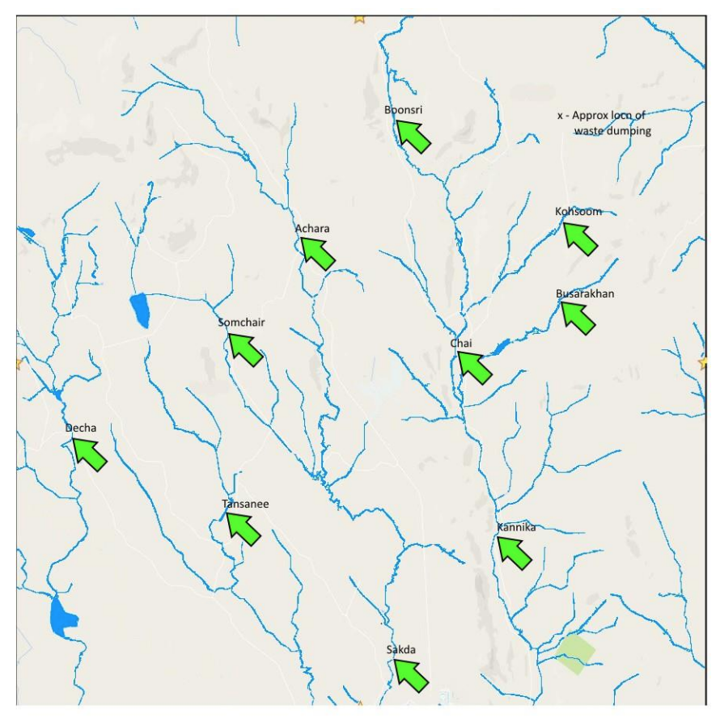

```python
Image(filename = "map.png", width = 400)
```

From the map above, the locations nearest to the waste dumping site are Boonsori, Kohsoom, Busarakhan and Chai. It also looks like their streams are connected along with Kannika.

## Creating Location-Measure Time Series Dashboard

Creating a locations dropdown for filtering

```python
locations_dropdown = alt.binding_select(options=locations)
```

```python
locations_selection = alt.selection_single(
    fields=['location'], bind=locations_dropdown, name='Select ')
```

```python
measures_selection = alt.selection_multi(fields=['measure'], bind='legend')
```

```python
# Filter the dataframe for only the measures of interest
interest_df = df[df['measure'].isin(top_10_by_count)]
```

```python
alt.Chart(
    interest_df, title=("Sensor readings for the most frequent measures")
).mark_line().encode(
    x=alt.X('sample_date:T', axis=alt.Axis(title='Date', grid=False)),
    y=alt.Y('value', axis=alt.Axis(title='Value')),
    color=alt.Color('measure:N', scale=alt.Scale(domain=top_10_by_count)),
    tooltip=['location', 'measure', 'value', 'sample_date']
).add_selection(
    measures_selection,
    locations_selection
).transform_filter(
    measures_selection
).transform_filter(
    locations_selection
).properties(
    width=800,
    height=500
)
```

[interactive chart not shown]

### Insights

There are very high spikes in the values of Manganese. This has promted a further view of Manganese across the locations.

```python
display(Markdown("### Time series for Manganese"))
plot_measure_time_series(df, 'Manganese')
```

Time series for Manganese

[interactive chart not shown]

```python
display(Markdown("### Time series for Manganese clamped at 2"))
plot_measure_time_series(df, 'Manganese', (0, 2))
```

Time series for Manganese clamped at 2

[interactive chart not shown]

```python
# saving the cleaned dataframe to a csv file
df.to_csv('cleaned_dataset.csv', index=False)
```